# Homework 2 & 3

## Part C

```r
library("data.table")
library("rlist")

# Read in data and arrange variable types
consumption = fread("GercekZamanliTuketim-01012016-19052020.csv")
setnames(consumption,names(consumption)[3],'value')
consumption[,date:=as.Date(Tarih,'%d.%m.%Y')]
consumption[,hour:=as.numeric(substr(Saat,1,2))]
consumption=consumption[,list(date,hour,value)]
consumption[,value:=gsub(".", "",value, fixed = TRUE)]
consumption[,value:=as.numeric(gsub(",", ".",value, fixed = TRUE))]

# Shift data and clear N/A
consumption = consumption[,lag_48:=shift(consumption[,3],48)]
consumption = consumption[,lag_168:=shift(consumption[,3],168)]
full_consumption = consumption[complete.cases(consumption)]
```

We created training and test sets in wide format.

```r
# Create training and test consumption data in wide format with lag_168
long_tr = full_consumption[date < '2020-03-01']
long_te = full_consumption[date >= '2020-03-01']
wide_tr = merge(dcast(long_tr,date~paste0('actual_hour_',hour), value.var='value'), dcast(long_tr,date~paste0('lag_168_hour_',hour),value.var='lag_168'), by = 'date')
wide_te = merge(dcast(long_te,date~paste0('actual_hour_',hour), value.var='value'), dcast(long_te,date~paste0('lag_168_hour_',hour),value.var='lag_168'), by = 'date')
```

We fitted the linear regression models for each hour, using training dataset.

```r
# Fit linear regression models
wide_fit_0 = lm(actual_hour_0~lag_168_hour_0, wide_tr)
wide_fit_1 = lm(actual_hour_1~lag_168_hour_1, wide_tr)
wide_fit_2 = lm(actual_hour_2~lag_168_hour_2, wide_tr)
wide_fit_3 = lm(actual_hour_0~lag_168_hour_3, wide_tr)
wide_fit_4 = lm(actual_hour_0~lag_168_hour_4, wide_tr)
wide_fit_5 = lm(actual_hour_0~lag_168_hour_5, wide_tr)
wide_fit_6 = lm(actual_hour_0~lag_168_hour_6, wide_tr)
wide_fit_7 = lm(actual_hour_0~lag_168_hour_7, wide_tr)
wide_fit_8 = lm(actual_hour_0~lag_168_hour_8, wide_tr)
wide_fit_9 = lm(actual_hour_0~lag_168_hour_9, wide_tr)
wide_fit_10 = lm(actual_hour_0~lag_168_hour_10, wide_tr)
wide_fit_11 = lm(actual_hour_0~lag_168_hour_11, wide_tr)
wide_fit_12 = lm(actual_hour_0~lag_168_hour_12, wide_tr)
wide_fit_13 = lm(actual_hour_0~lag_168_hour_13, wide_tr)
wide_fit_14 = lm(actual_hour_0~lag_168_hour_14, wide_tr)
wide_fit_15 = lm(actual_hour_0~lag_168_hour_15, wide_tr)
wide_fit_16 = lm(actual_hour_0~lag_168_hour_16, wide_tr)
wide_fit_17 = lm(actual_hour_0~lag_168_hour_17, wide_tr)
wide_fit_18 = lm(actual_hour_0~lag_168_hour_18, wide_tr)
wide_fit_19 = lm(actual_hour_0~lag_168_hour_19, wide_tr)
wide_fit_20 = lm(actual_hour_0~lag_168_hour_20, wide_tr)
wide_fit_21 = lm(actual_hour_0~lag_168_hour_21, wide_tr)
wide_fit_22 = lm(actual_hour_0~lag_168_hour_22, wide_tr)
wide_fit_23 = lm(actual_hour_0~lag_168_hour_23, wide_tr)
```

We performed the predictions using the lm models for each hour, and created a wide format table with predicted consumption.

```r
# Make prediction with linear regression models
wide_pred_0 = predict(wide_fit_0, wide_te)
wide_pred_1 = predict(wide_fit_1, wide_te)
wide_pred_2 = predict(wide_fit_2, wide_te)
wide_pred_3 = predict(wide_fit_3, wide_te)
wide_pred_4 = predict(wide_fit_4, wide_te)
wide_pred_5 = predict(wide_fit_5, wide_te)
wide_pred_6 = predict(wide_fit_6, wide_te)
wide_pred_7 = predict(wide_fit_7, wide_te)
wide_pred_8 = predict(wide_fit_8, wide_te)
wide_pred_9 = predict(wide_fit_9, wide_te)
wide_pred_10 = predict(wide_fit_10, wide_te)
wide_pred_11 = predict(wide_fit_11, wide_te)
wide_pred_12 = predict(wide_fit_12, wide_te)
wide_pred_13 = predict(wide_fit_13, wide_te)
wide_pred_14 = predict(wide_fit_14, wide_te)
wide_pred_15 = predict(wide_fit_15, wide_te)
wide_pred_16 = predict(wide_fit_16, wide_te)
wide_pred_17 = predict(wide_fit_17, wide_te)
wide_pred_18 = predict(wide_fit_18, wide_te)
wide_pred_19 = predict(wide_fit_19, wide_te)
wide_pred_20 = predict(wide_fit_20, wide_te)
wide_pred_21 = predict(wide_fit_21, wide_te)
wide_pred_22 = predict(wide_fit_22, wide_te)
wide_pred_23 = predict(wide_fit_23, wide_te)

# Create wide format table with predicted consumption
wide_predicted = wide_te[, 1:25]
wide_predicted = wide_predicted[, predicted_0 := wide_pred_0]
wide_predicted = wide_predicted[, predicted_1 := wide_pred_1]
wide_predicted = wide_predicted[, predicted_2 := wide_pred_2]
wide_predicted = wide_predicted[, predicted_3 := wide_pred_3]
wide_predicted = wide_predicted[, predicted_4 := wide_pred_4]
wide_predicted = wide_predicted[, predicted_5 := wide_pred_5]
wide_predicted = wide_predicted[, predicted_6 := wide_pred_6]
wide_predicted = wide_predicted[, predicted_7 := wide_pred_7]
wide_predicted = wide_predicted[, predicted_8 := wide_pred_8]
wide_predicted = wide_predicted[, predicted_9 := wide_pred_9]
wide_predicted = wide_predicted[, predicted_10 := wide_pred_10]
wide_predicted = wide_predicted[, predicted_11 := wide_pred_11]
wide_predicted = wide_predicted[, predicted_12 := wide_pred_12]
wide_predicted = wide_predicted[, predicted_13 := wide_pred_13]
wide_predicted = wide_predicted[, predicted_14 := wide_pred_14]
wide_predicted = wide_predicted[, predicted_15 := wide_pred_15]
wide_predicted = wide_predicted[, predicted_16 := wide_pred_16]
wide_predicted = wide_predicted[, predicted_17 := wide_pred_17]
wide_predicted = wide_predicted[, predicted_18 := wide_pred_18]
wide_predicted = wide_predicted[, predicted_19 := wide_pred_19]
wide_predicted = wide_predicted[, predicted_20 := wide_pred_20]
wide_predicted = wide_predicted[, predicted_21 := wide_pred_21]
wide_predicted = wide_predicted[, predicted_22 := wide_pred_22]
wide_predicted = wide_predicted[, predicted_23 := wide_pred_23]
```

We calculated the APE and MAPE for predictions.

```r
# calculate APE for predicted consumption
wide_predicted = wide_predicted[, APE_H0:=(abs(wide_predicted$actual_hour_0-wide_predicted$predicted_0)/abs(wide_predicted$actual_hour_0))*100]
wide_predicted = wide_predicted[, APE_H1:=(abs(wide_predicted$actual_hour_1-wide_predicted$predicted_1)/abs(wide_predicted$actual_hour_1))*100]
wide_predicted = wide_predicted[, APE_H2:=(abs(wide_predicted$actual_hour_2-wide_predicted$predicted_2)/abs(wide_predicted$actual_hour_2))*100]
wide_predicted = wide_predicted[, APE_H3:=(abs(wide_predicted$actual_hour_3-wide_predicted$predicted_3)/abs(wide_predicted$actual_hour_3))*100]
wide_predicted = wide_predicted[, APE_H4:=(abs(wide_predicted$actual_hour_4-wide_predicted$predicted_4)/abs(wide_predicted$actual_hour_4))*100]
wide_predicted = wide_predicted[, APE_H5:=(abs(wide_predicted$actual_hour_5-wide_predicted$predicted_5)/abs(wide_predicted$actual_hour_5))*100]
wide_predicted = wide_predicted[, APE_H6:=(abs(wide_predicted$actual_hour_6-wide_predicted$predicted_6)/abs(wide_predicted$actual_hour_6))*100]
wide_predicted = wide_predicted[, APE_H7:=(abs(wide_predicted$actual_hour_7-wide_predicted$predicted_7)/abs(wide_predicted$actual_hour_7))*100]
wide_predicted = wide_predicted[, APE_H8:=(abs(wide_predicted$actual_hour_8-wide_predicted$predicted_8)/abs(wide_predicted$actual_hour_8))*100]
wide_predicted = wide_predicted[, APE_H9:=(abs(wide_predicted$actual_hour_9-wide_predicted$predicted_9)/abs(wide_predicted$actual_hour_9))*100]
wide_predicted = wide_predicted[, APE_H10:=(abs(wide_predicted$actual_hour_10-wide_predicted$predicted_10)/abs(wide_predicted$actual_hour_10))*100]
wide_predicted = wide_predicted[, APE_H11:=(abs(wide_predicted$actual_hour_11-wide_predicted$predicted_11)/abs(wide_predicted$actual_hour_11))*100]
wide_predicted = wide_predicted[, APE_H12:=(abs(wide_predicted$actual_hour_12-wide_predicted$predicted_12)/abs(wide_predicted$actual_hour_12))*100]
wide_predicted = wide_predicted[, APE_H13:=(abs(wide_predicted$actual_hour_13-wide_predicted$predicted_13)/abs(wide_predicted$actual_hour_13))*100]
wide_predicted = wide_predicted[, APE_H14:=(abs(wide_predicted$actual_hour_14-wide_predicted$predicted_14)/abs(wide_predicted$actual_hour_14))*100]
wide_predicted = wide_predicted[, APE_H15:=(abs(wide_predicted$actual_hour_15-wide_predicted$predicted_15)/abs(wide_predicted$actual_hour_15))*100]
wide_predicted = wide_predicted[, APE_H16:=(abs(wide_predicted$actual_hour_16-wide_predicted$predicted_16)/abs(wide_predicted$actual_hour_16))*100]
wide_predicted = wide_predicted[, APE_H17:=(abs(wide_predicted$actual_hour_17-wide_predicted$predicted_17)/abs(wide_predicted$actual_hour_17))*100]
wide_predicted = wide_predicted[, APE_H18:=(abs(wide_predicted$actual_hour_18-wide_predicted$predicted_18)/abs(wide_predicted$actual_hour_18))*100]
wide_predicted = wide_predicted[, APE_H19:=(abs(wide_predicted$actual_hour_19-wide_predicted$predicted_19)/abs(wide_predicted$actual_hour_19))*100]
wide_predicted = wide_predicted[, APE_H20:=(abs(wide_predicted$actual_hour_20-wide_predicted$predicted_20)/abs(wide_predicted$actual_hour_20))*100]
wide_predicted = wide_predicted[, APE_H21:=(abs(wide_predicted$actual_hour_21-wide_predicted$predicted_21)/abs(wide_predicted$actual_hour_21))*100]
wide_predicted = wide_predicted[, APE_H22:=(abs(wide_predicted$actual_hour_22-wide_predicted$predicted_22)/abs(wide_predicted$actual_hour_22))*100]
wide_predicted = wide_predicted[, APE_H23:=(abs(wide_predicted$actual_hour_23-wide_predicted$predicted_23)/abs(wide_predicted$actual_hour_23))*100]

# calculate MAPE for predicted consumption
wide_MAPE_0 = mean(wide_predicted$APE_H0)
wide_MAPE_1 = mean(wide_predicted$APE_H1)
wide_MAPE_2 = mean(wide_predicted$APE_H2)
wide_MAPE_3 = mean(wide_predicted$APE_H3)
wide_MAPE_4 = mean(wide_predicted$APE_H4)
wide_MAPE_5 = mean(wide_predicted$APE_H5)
wide_MAPE_6 = mean(wide_predicted$APE_H6)
wide_MAPE_7 = mean(wide_predicted$APE_H7)
wide_MAPE_8 = mean(wide_predicted$APE_H8)
wide_MAPE_9 = mean(wide_predicted$APE_H9)
wide_MAPE_10 = mean(wide_predicted$APE_H10)
wide_MAPE_11 = mean(wide_predicted$APE_H11)
wide_MAPE_12 = mean(wide_predicted$APE_H12)
wide_MAPE_13 = mean(wide_predicted$APE_H13)
wide_MAPE_14 = mean(wide_predicted$APE_H14)
wide_MAPE_15 = mean(wide_predicted$APE_H15)
wide_MAPE_16 = mean(wide_predicted$APE_H16)
wide_MAPE_17 = mean(wide_predicted$APE_H17)
wide_MAPE_18 = mean(wide_predicted$APE_H18)
wide_MAPE_19 = mean(wide_predicted$APE_H19)
wide_MAPE_20 = mean(wide_predicted$APE_H20)
wide_MAPE_21 = mean(wide_predicted$APE_H21)
wide_MAPE_22 = mean(wide_predicted$APE_H22)
wide_MAPE_23 = mean(wide_predicted$APE_H23)
```

We checked out the summary statistics to better understand the prediction error distributions.

```r
# Display summary statistics
summary(wide_predicted$APE_H0)
```

```
##     Min.  1st Qu.   Median     Mean  3rd Qu.     Max.
##  0.03091  1.25424  3.71368  4.37286  6.53782 17.12464
```

```r
quantile(wide_predicted$APE_H0, probs = c(0.1, 0.25, 0.5, 0.75, 0.9))
```

```
##       10%       25%       50%       75%       90%
## 0.4862432 1.2542413 3.7136794 6.5378200 8.5477957
```

```r
summary(wide_predicted$APE_H1)
```

```
##     Min.  1st Qu.   Median     Mean  3rd Qu.     Max.
##  0.05774  1.46751  4.05013  4.42039  6.52903 17.29339
```

```r
quantile(wide_predicted$APE_H1, probs = c(0.1, 0.25, 0.5, 0.75, 0.9))
```

```
##       10%       25%       50%       75%       90%
## 0.5616984 1.4675070 4.0501246 6.5290336 8.3936829
```

```r
summary(wide_predicted$APE_H2)
```

```
##     Min.  1st Qu.   Median     Mean  3rd Qu.     Max.
##  0.01982  1.37021  4.52609  4.65492  7.36666 17.01919
```

```r
quantile(wide_predicted$APE_H2, probs = c(0.1, 0.25, 0.5, 0.75, 0.9))
```

```
##       10%       25%       50%       75%       90%
## 0.5973676 1.3702126 4.5260922 7.3666602 8.3543642
```

```r
summary(wide_predicted$APE_H3)
```

```
##    Min. 1st Qu.  Median    Mean 3rd Qu.    Max.
##   1.749  11.638  15.091  15.564  20.824  33.057
```

```r
quantile(wide_predicted$APE_H3, probs = c(0.1, 0.25, 0.5, 0.75, 0.9))
```

```
##      10%      25%      50%      75%      90%
##  7.41536 11.63776 15.09053 20.82352 22.20529
```

```r
summary(wide_predicted$APE_H4)
```

```
##    Min. 1st Qu.  Median    Mean 3rd Qu.    Max.
##   3.811  13.383  16.994  17.371  22.431  34.490
```

```r
quantile(wide_predicted$APE_H4, probs = c(0.1, 0.25, 0.5, 0.75, 0.9))
```

```
##       10%       25%       50%       75%       90%
##  8.980602 13.383169 16.993887 22.430710 24.322582
```

```r
summary(wide_predicted$APE_H5)
```

```
##    Min. 1st Qu.  Median    Mean 3rd Qu.    Max.
##   7.514  15.664  19.542  19.694  23.730  36.515
```

```r
quantile(wide_predicted$APE_H5, probs = c(0.1, 0.25, 0.5, 0.75, 0.9))
```

```
##      10%      25%      50%      75%      90%
## 12.51076 15.66442 19.54248 23.73049 27.08139
```

```r
summary(wide_predicted$APE_H6)
```

```
##    Min. 1st Qu.  Median    Mean 3rd Qu.    Max.
##   8.246  17.061  23.371  22.728  27.755  44.199
```

```r
quantile(wide_predicted$APE_H6, probs = c(0.1, 0.25, 0.5, 0.75, 0.9))
```

```
##      10%      25%      50%      75%      90%
## 10.41912 17.06122 23.37100 27.75451 33.04800
```

```r
summary(wide_predicted$APE_H7)
```

```
##    Min. 1st Qu.  Median    Mean 3rd Qu.    Max.
##    3.78   16.44   21.86   22.22   28.50   51.15
```

```r
quantile(wide_predicted$APE_H7, probs = c(0.1, 0.25, 0.5, 0.75, 0.9))
```

```
##       10%       25%       50%       75%       90%
##  5.449933 16.435842 21.859515 28.501244 38.793394
```

```r
summary(wide_predicted$APE_H8)
```

```
##    Min. 1st Qu.  Median    Mean 3rd Qu.    Max.
##   1.512   8.476  13.520  17.442  20.383  60.771
```

```r
quantile(wide_predicted$APE_H8, probs = c(0.1, 0.25, 0.5, 0.75, 0.9))
```

```
##       10%       25%       50%       75%       90%
##  5.328471  8.476098 13.519514 20.382856 36.988564
```

```r
summary(wide_predicted$APE_H9)
```

```
##    Min. 1st Qu.  Median    Mean 3rd Qu.    Max.
##  0.7052  5.8566 11.7804 14.9110 17.3066 62.5129
```

```r
quantile(wide_predicted$APE_H9, probs = c(0.1, 0.25, 0.5, 0.75, 0.9))
```

```
##       10%       25%       50%       75%       90%
##  2.169617  5.856620 11.780439 17.306552 34.577273
```

```r
summary(wide_predicted$APE_H10)
```

```
##     Min.  1st Qu.   Median     Mean  3rd Qu.     Max.
##  0.02245  3.57588  9.85948 12.83456 18.56747 58.27387
```

```r
quantile(wide_predicted$APE_H10, probs = c(0.1, 0.25, 0.5, 0.75, 0.9))
```

```
##       10%       25%       50%       75%       90%
##  1.787553  3.575880  9.859479 18.567472 30.180950
```

```r
summary(wide_predicted$APE_H11)
```

```
##    Min. 1st Qu.  Median    Mean 3rd Qu.    Max.
##  0.2929  3.8709  7.2819 11.3361 15.4001 51.7869
```

```r
quantile(wide_predicted$APE_H11, probs = c(0.1, 0.25, 0.5, 0.75, 0.9))
```

```
##       10%       25%       50%       75%       90%
##  1.223263  3.870909  7.281891 15.400133 25.356553
```

```r
summary(wide_predicted$APE_H12)
```

```
##    Min. 1st Qu.  Median    Mean 3rd Qu.    Max.
##  0.1122  2.9461  6.9760 10.0373 13.6592 47.6097
```

```r
quantile(wide_predicted$APE_H12, probs = c(0.1, 0.25, 0.5, 0.75, 0.9))
```

```
##       10%       25%       50%       75%       90%
##  1.576649  2.946093  6.975971 13.659158 21.724151
```

```r
summary(wide_predicted$APE_H13)
```

```
##    Min. 1st Qu.  Median    Mean 3rd Qu.    Max.
##  0.1414  3.3861  6.1866  9.2992 12.8039 45.0147
```

```r
quantile(wide_predicted$APE_H13, probs = c(0.1, 0.25, 0.5, 0.75, 0.9))
```

```
##       10%       25%       50%       75%       90%
##  1.023881  3.386071  6.186594 12.803914 20.659264
```

```r
summary(wide_predicted$APE_H14)
```

```
##     Min.  1st Qu.   Median     Mean  3rd Qu.     Max.
##  0.04451  3.69817  6.97402  9.41273 13.15296 44.42113
```

```r
quantile(wide_predicted$APE_H14, probs = c(0.1, 0.25, 0.5, 0.75, 0.9))
```

```
##        10%        25%        50%        75%        90%
##  0.9512929  3.6981740  6.9740182 13.1529627 19.4100127
```

```r
summary(wide_predicted$APE_H15)
```

```
##     Min.  1st Qu.   Median     Mean  3rd Qu.     Max.
##  0.05971  3.76325  6.75082  8.93436 12.30857 40.05998
```

```r
quantile(wide_predicted$APE_H15, probs = c(0.1, 0.25, 0.5, 0.75, 0.9))
```

```
##       10%       25%       50%       75%       90%
##  1.443558  3.763253  6.750822 12.308567 18.467889
```

```r
summary(wide_predicted$APE_H16)
```

```
##    Min. 1st Qu.  Median    Mean 3rd Qu.    Max.
##   0.161   3.873   7.121   8.606  11.883  34.222
```

```r
quantile(wide_predicted$APE_H16, probs = c(0.1, 0.25, 0.5, 0.75, 0.9))
```

```
##       10%       25%       50%       75%       90%
##  2.231547  3.873087  7.120862 11.882563 17.557349
```

```r
summary(wide_predicted$APE_H17)
```

```
##    Min. 1st Qu.  Median    Mean 3rd Qu.    Max.
##  0.2683  3.7194  6.8442  8.0131 10.5073 24.9968
```

```r
quantile(wide_predicted$APE_H17, probs = c(0.1, 0.25, 0.5, 0.75, 0.9))
```

```
##       10%       25%       50%       75%       90%
##  1.968434  3.719404  6.844190 10.507338 14.668786
```

```r
summary(wide_predicted$APE_H18)
```

```
##     Min.  1st Qu.   Median     Mean  3rd Qu.     Max.
##  0.02617  3.67857  6.98089  7.49116 10.51716 19.47231
```

```r
quantile(wide_predicted$APE_H18, probs = c(0.1, 0.25, 0.5, 0.75, 0.9))
```

```
##       10%       25%       50%       75%       90%
##  1.781759  3.678568  6.980888 10.517157 14.178669
```

```r
summary(wide_predicted$APE_H19)
```

```
##    Min. 1st Qu.  Median    Mean 3rd Qu.    Max.
##  0.1149  6.5742  8.3222  9.0132 12.5364 19.7619
```

```r
quantile(wide_predicted$APE_H19, probs = c(0.1, 0.25, 0.5, 0.75, 0.9))
```

```
##       10%       25%       50%       75%       90%
##  2.822575  6.574154  8.322249 12.536404 15.205228
```

```r
summary(wide_predicted$APE_H20)
```

```
##    Min. 1st Qu.  Median    Mean 3rd Qu.    Max.
##  0.1998  6.4409  8.5501  9.2051 12.4935 18.5262
```

```r
quantile(wide_predicted$APE_H20, probs = c(0.1, 0.25, 0.5, 0.75, 0.9))
```

```
##       10%       25%       50%       75%       90%
##  4.505608  6.440950  8.550050 12.493457 14.458362
```

```r
summary(wide_predicted$APE_H21)
```

```
##     Min.  1st Qu.   Median     Mean  3rd Qu.     Max.
##  0.02217  5.07573  8.12066  8.09262 11.33670 16.30168
```

```r
quantile(wide_predicted$APE_H21, probs = c(0.1, 0.25, 0.5, 0.75, 0.9))
```

```
##       10%       25%       50%       75%       90%
##  2.940776  5.075735  8.120663 11.336701 13.151602
```

```r
summary(wide_predicted$APE_H22)
```

```
##    Min. 1st Qu.  Median    Mean 3rd Qu.    Max.
##  0.2275  3.7274  6.0373  6.4651  9.4742 14.6195
```

```r
quantile(wide_predicted$APE_H22, probs = c(0.1, 0.25, 0.5, 0.75, 0.9))
```

```
##       10%       25%       50%       75%       90%
##  1.558514  3.727411  6.037332  9.474173 10.966660
```

```r
summary(wide_predicted$APE_H23)
```

```
##     Min.  1st Qu.   Median     Mean  3rd Qu.     Max.
##  0.05222  1.51538  3.28717  4.07788  6.30070 12.25404
```

```r
quantile(wide_predicted$APE_H23, probs = c(0.1, 0.25, 0.5, 0.75, 0.9))
```

```
##       10%       25%       50%       75%       90%
## 0.2756153 1.5153759 3.2871658 6.3007031 9.0123930
```

We also plotted a boxplot to see the variability visually.

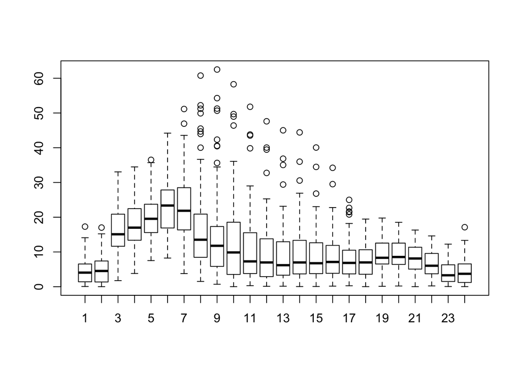

```r
# Plot a boxplot for hourly APE
boxplot(wide_predicted$APE_H1, wide_predicted$APE_H2, wide_predicted$APE_H3, wide_predicted$APE_H4,wide_predicted$APE_H5,wide_predicted$APE_H6, wide_predicted$APE_H7, wide_predicted$APE_H8, wide_predicted$APE_H9, wide_predicted$APE_H10,wide_predicted$APE_H11, wide_predicted$APE_H12, wide_predicted$APE_H13, wide_predicted$APE_H14, wide_predicted$APE_H15, wide_predicted$APE_H16, wide_predicted$APE_H17, wide_predicted$APE_H18, wide_predicted$APE_H19, wide_predicted$APE_H20, wide_predicted$APE_H21, wide_predicted$APE_H22, wide_predicted$APE_H23, wide_predicted$APE_H0)
```

Additional Note: We are aware of that there might be a better way of code but we kept our focus on the result rather than the scripting language.